# FIA - NLS Models: Biomass Growth vs. Stand Age, Temporally-Balanced, No Harvest

## predict and plot

[figure not shown]

## plotting 2

[figure not shown]

# M223 - Ozark Broadleaf Forest Meadow

## model selection 1

```
## Error in nls(fg2_1, data = G_M223, start = c(ge = ge.start, a = a.start,  :
##   number of iterations exceeded maximum of 50
```

```
## Error in numericDeriv(form[[3L]], names(ind), env, central = nDcentral) :
##   Missing value or an infinity produced when evaluating the model
```

```
## Error in numericDeriv(form[[3L]], names(ind), env, central = nDcentral) :
##   Missing value or an infinity produced when evaluating the model
##   model AIC
## 1     1  NA
## 2     2  NA
## 3     3  NA
```

```
## Error in h(simpleError(msg, call)) :
##   error in evaluating the argument 'object' in selecting a method for function 'summary': object 'nls_M223.' not found
```

### summary

- simple model: does not fit
- phi model: does not fit
- phi-alpha model: does not fit

## plot residuals

```
## [1] "cannot plot residuals"
```

## predict and plot

```
## [1] "cannot plot data with prediction"
```

## plotting 2

# M231 - Ouachita Mixed Forest

## model selection 1

```
## Error in nls(fg2_2, data = G_M231, start = c(ge = ge.start, phi = phi.start,  :
##   singular gradient
## Error in nls(fg2_3, data = G_M231, start = c(ge = ge.start, phi = phi.start,  :
##   singular gradient
##   model      AIC
## 1     1 2351.735
## 2     2       NA
## 3     3       NA
```

```
##
## Formula: G_obs_TreeInc_MgHaYr ~ (1 + (MEASTIME_avg - 1990) * ge/100) *
##     (a + b * exp(-((log(STDAGE_t1/c))/d)^2))
##
## Parameters:
##    Estimate Std. Error t value Pr(>|t|)
## ge   3.3527     1.9780   1.695   0.0906 .
## a    1.4938     0.3764   3.968 8.15e-05 ***
## b    0.7378     0.3345   2.206   0.0278 *
## c   26.5819     2.6129  10.173  < 2e-16 ***
## d    0.2484     0.1201   2.069   0.0390 *
## ---
## Signif. codes:  0 '***' 0.001 '**' 0.01 '*' 0.05 '.' 0.1 ' ' 1
##
## Residual standard error: 1.106 on 577 degrees of freedom
##
## Number of iterations to convergence: 19
## Achieved convergence tolerance: 5.93e-06
##   (2 observations deleted due to missingness)
```

### summary

- simple model: fits
- phi model: does not fit
- phi-alpha model: does not fit

## plot residuals

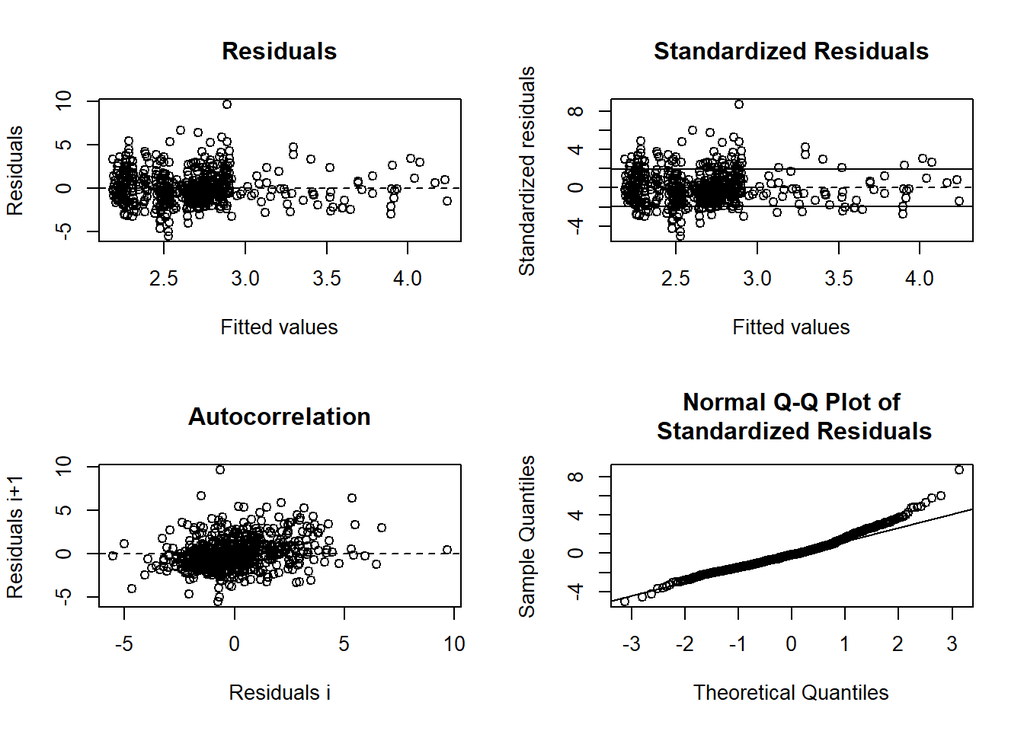

```
##
## ------
##  Shapiro-Wilk normality test
##
## data:  stdres
## W = 0.96873, p-value = 8.356e-10
##
##
## ------
```

```
##
##  Runs Test
##
## data:  as.factor(run)
## Standard Normal = -6.25, p-value = 4.105e-10
## alternative hypothesis: two.sided
```

## predict and plot

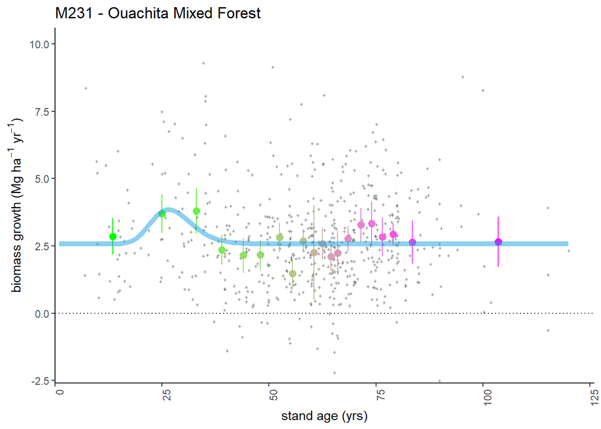

## plotting 2

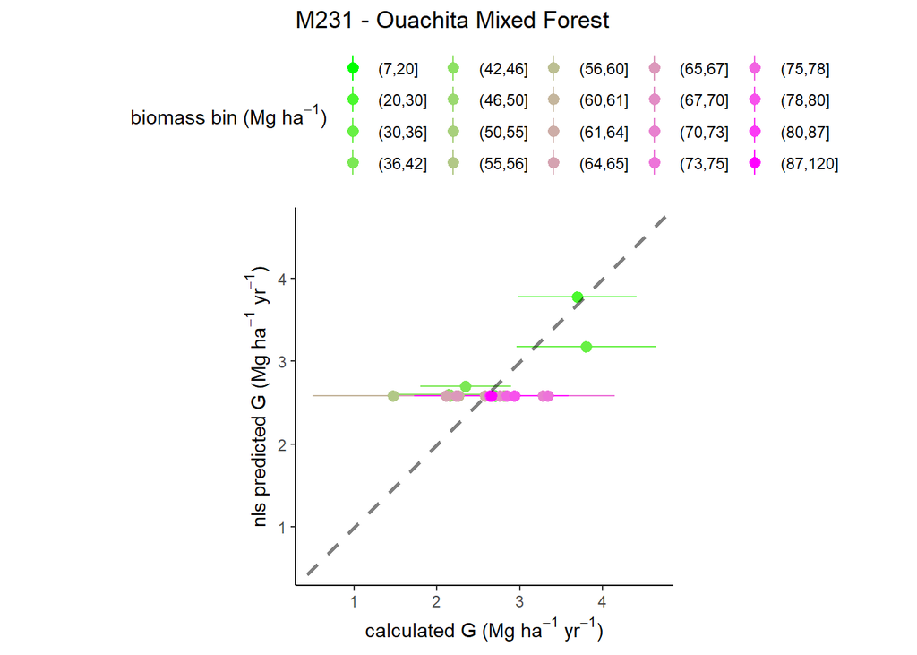

# M242 - Cascade Mixed Forest

## model selection 1

### summary

- simple model: does not fit
- phi model: does not fit
- phi-alpha model: does not fit

## plot residuals

```
## [1] "cannot plot residuals"
```

## predict and plot

```
## [1] "cannot plot data with prediction"
```

## plotting 2

# M261 - Sierran Steppe - Mixed Forest - Coniferous Forest - Alpine Meadow

## model selection 1

### summary

- simple model: does not fit
- phi model: does not fit
- phi-alpha model: does not fit

## plot residuals

```
## [1] "cannot plot residuals"
```

## predict and plot

```
## [1] "cannot plot data with prediction"
```

## plotting 2

# M262 - Califormia Coastal Range = Coniferous Forest - Open woodland Shrub Meadow

## model selection 1

### summary

- simple model: does not fit
- phi model: does not fit
- phi-alpha model: does not fit

## plot residuals

```
## [1] "cannot plot residuals"
```

## predict and plot

```
## [1] "cannot plot data with prediction"
```

## plotting 2

# M313 - Arizona-New Mexico Mountains Semi-Desert - Open Woodland - Coniferous Forest - Alpine Meadow

## model selection 1

### summary

- simple model: does not fit
- phi model: does not fit
- phi-alpha model: does not fit

## plot residuals

```
## [1] "cannot plot residuals"
```

## predict and plot

```
## [1] "cannot plot data with prediction"
```

## plotting 2

# M331 - Southern Rocky Mountain Steppe - Open Woodland - Coniferous Forest - Alpine Meadow

## model selection 1

### summary

- simple model: does not fit
- phi model: does not fit
- phi-alpha model: does not fit

## plot residuals

```
## [1] "cannot plot residuals"
```

## predict and plot

```
## [1] "cannot plot data with prediction"
```

## plotting 2

# M332 - Middle Rocky Mountain Steppe - Coniferous Forest - Alpine Meadow

## model selection 1

### summary

- simple model: does not fit
- phi model: does not fit
- phi-alpha model: does not fit

## plot residuals

```
## [1] "cannot plot residuals"
```

## predict and plot

```
## [1] "cannot plot data with prediction"
```

## plotting 2

# M333 - Northern Rocky Mountain Steppe - Coniferous Forest - Alpine Meadow

## model selection 1

[output not shown]

```
## Error in h(simpleError(msg, call)) :
##   error in evaluating the argument 'object' in selecting a method for function 'summary': object 'nls_M333.' not found
```

### summary

- simple model: does not fit
- phi model: does not fit
- phi-alpha model: does not fit

## plot residuals

```
## [1] "cannot plot residuals"
```

## predict and plot

```
## [1] "cannot plot data with prediction"
```

## plotting 2

# M334 - Black Hills Coniferous Forest

## model selection 1

### summary

- simple model: does not fit
- phi model: does not fit
- phi-alpha model: does not fit

## plot residuals

```
## [1] "cannot plot residuals"
```

## predict and plot

```
## [1] "cannot plot data with prediction"
```

## plotting 2

# M341 - Nevada-Utah Mountains Semi-Desert - Coniferous Forest - Alpine Meadow

## model selection 1

### summary

- simple model: does not fit
- phi model: does not fit
- phi-alpha model: does not fit

## plot residuals

```
## [1] "cannot plot residuals"
```

## predict and plot

```
## [1] "cannot plot data with prediction"
```

## plotting 2

# Fitted parameters

## Best / selected models by ecoprovince

| Code | Ecoregion | Sel.Mod |
| --- | --- | --- |
| 211 | Northeastern Mixed Forest | NA |
| 212 | Laurentian Mixed Forest | 3 |
| 221 | Eastern Broadleaf Forest | NA |
| 222 | Midwest Broadleaf Forest | NA |
| 223 | Central Interior Broadleaf Forest | 3 |
| 231 | Southeastern Mixed Forest | 3 |
| 232 | Outer Coastal Plain Mixed Forest | 3 |
| 234 | Lower Mississippi Riverine Forest | 3 |
| 242 | Pacific Lowland Mixed Forest | NA |
| 251 | Prairie Parkland (Temperate) | NA |
| 255 | Prairie Parkland (Subtropical) | NA |
| 261 | California Coastal Chaparral Forest and Shrub | NA |
| 262 | California Dry Steppe | NA |
| 263 | California Coastal Steppe - Mixed Forest and Redwood Forest | NA |
| 313 | Colorado Plateau Semi-Desert | NA |
| 315 | Southwest Plateau and Plains Dry Steppe and Shrub | NA |
| 321 | Chihuahuan Semi-Desert | NA |
| 322 | American Semidesert and Desert | NA |
| 331 | Great Plains/Palouse Dry Steppe | NA |
| 332 | Great Plains Steppe | NA |
| 341 | Intermountain Semi-Desert and Desert | NA |
| 342 | Intermountain Semi-Desert | NA |
| 411 | Everglades | NA |
| M211 | Adirondack-New England Mixed forest - Coniferous Forest - Alpine Meadow | 3 |
| M221 | Central Appalachian Broadleaf Forest - Coniferous Forest - Meadow | 3 |
| M223 | Ozark Broadleaf Forest Meadow | NA |
| M231 | Ouachita Mixed Forest | 1 |
| M242 | Cascade Mixed Forest | NA |
| M261 | Sierran Steppe - Mixed Forest - Coniferous Forest - Alpine Meadow | NA |
| M262 | California Coastal Range Coniferous Forest - Open Woodland - Shrub - Meadow | NA |
| M313 | Arizona-New Mexico Mountains Semi-Desert - Open Woodland - Coniferous Forest - Alpine Meadow | NA |
| M331 | Southern Rocky Mountain Steppe - Open Woodland - Coniferous Forest - Alpine Meadow | NA |
| M332 | Middle Rocky Mountain Steppe - Coniferous Forest - Alpine Meadow | NA |
| M333 | Northern Rocky Mountain Steppe - Coniferous Forest - Alpine Meadow | NA |
| M334 | Black Hills Coniferous Forest | NA |
| M341 | Nevada-Utah Mountains Semi-Desert - Coniferous Forest - Alpine Meadow | NA |

## table by ecoprovince

| Code | Ecoregion | region | n.obs | n.plots | ge | ge.2.5 | ge.97.5 | phi | phi.2.5 | phi.97.5 | alpha | alpha.2.5 | alpha.97.5 | a | a.2.5 | a.97.5 | b | b.2.5 | b.97.5 | c | c.2.5 | c.97.5 | d | d.2.5 | d.97.5 |
| --- | --- | --- | --- | --- | --- | --- | --- | --- | --- | --- | --- | --- | --- | --- | --- | --- | --- | --- | --- | --- | --- | --- | --- | --- | --- |
| 211 | Northeastern Mixed Forest | east | 3714 | 1857 | NA | NA | NA | NA | NA | NA | NA | NA | NA | NA | NA | NA | NA | NA | NA | NA | NA | NA | NA | NA | NA |
| 212 | Laurentian Mixed Forest | east | 9658 | 4829 | 0.8755583 | 0.5230395 | 1.2280772 | 0.0287189 | 0.0202650 | 0.0371728 | 0.7273438 | 0.6359953 | 0.8186923 | 0.8530027 | 0.2790196 | 1.426986 | 1.7118091 | 1.1593821 | 2.2642362 | 20.00375 | 18.133467 | 21.87403 | 2.0407457 | 1.4926862 | 2.5888052 |
| 221 | Eastern Broadleaf Forest | east | 4386 | 2193 | NA | NA | NA | NA | NA | NA | NA | NA | NA | NA | NA | NA | NA | NA | NA | NA | NA | NA | NA | NA | NA |
| 222 | Midwest Broadleaf Forest | east | 2576 | 1288 | NA | NA | NA | NA | NA | NA | NA | NA | NA | NA | NA | NA | NA | NA | NA | NA | NA | NA | NA | NA | NA |
| 223 | Central Interior Broadleaf Forest | east | 5024 | 2512 | -1.0647717 | -1.3109146 | -0.8186287 | -0.0106677 | -0.0267045 | 0.0053691 | 0.5671091 | 0.4099925 | 0.7242258 | 2.8823021 | 1.9166032 | 3.848001 | 1.6928533 | 0.7610395 | 2.6246671 | 29.62230 | 24.796625 | 34.44797 | 1.2698063 | 0.6260490 | 1.9135635 |
| 231 | Southeastern Mixed Forest | east | 5952 | 2976 | -0.2615794 | -0.5022372 | -0.0209215 | -0.0017438 | -0.0130696 | 0.0095819 | 0.8393961 | 0.7121235 | 0.9666687 | 3.0525395 | 2.2829692 | 3.822110 | 3.5233607 | 2.7966915 | 4.2500300 | 18.88665 | 17.621280 | 20.15201 | 1.4628321 | 1.1678617 | 1.7578025 |
| 232 | Outer Coastal Plain Mixed Forest | east | 6120 | 3060 | 0.1365052 | -0.2139330 | 0.4869433 | -0.0016156 | -0.0143411 | 0.0111100 | 0.8063367 | 0.6917637 | 0.9209096 | 3.4453739 | 3.1113514 | 3.779396 | 2.2882367 | 1.9927053 | 2.5837680 | 16.63889 | 15.269974 | 18.00780 | 0.9477735 | 0.7827927 | 1.1127542 |
| 234 | Lower Mississippi Riverine Forest | east | 640 | 320 | -0.0992424 | -1.6018084 | 1.4033235 | 0.0178701 | -0.0409739 | 0.0767140 | 0.9303527 | 0.5952975 | 1.2654078 | 3.7171138 | 1.8896748 | 5.544553 | 1.6376492 | 0.1972925 | 3.0780059 | 21.41500 | 9.682164 | 33.14784 | 0.9307874 | -0.3111834 | 2.1727582 |
| 242 | Pacific Lowland Mixed Forest | pacific | 0 | 0 | NA | NA | NA | NA | NA | NA | NA | NA | NA | NA | NA | NA | NA | NA | NA | NA | NA | NA | NA | NA | NA |
| 251 | Prairie Parkland (Temperate) | east | 1112 | 556 | NA | NA | NA | NA | NA | NA | NA | NA | NA | NA | NA | NA | NA | NA | NA | NA | NA | NA | NA | NA | NA |
| 255 | Prairie Parkland (Subtropical) | pacific | 382 | 191 | NA | NA | NA | NA | NA | NA | NA | NA | NA | NA | NA | NA | NA | NA | NA | NA | NA | NA | NA | NA | NA |
| 261 | California Coastal Chaparral Forest and Shrub | pacific | 0 | 0 | NA | NA | NA | NA | NA | NA | NA | NA | NA | NA | NA | NA | NA | NA | NA | NA | NA | NA | NA | NA | NA |
| 262 | California Dry Steppe | pacific | 0 | 0 | NA | NA | NA | NA | NA | NA | NA | NA | NA | NA | NA | NA | NA | NA | NA | NA | NA | NA | NA | NA | NA |
| 263 | California Coastal Steppe - Mixed Forest and Redwood Forest | pacific | 0 | 0 | NA | NA | NA | NA | NA | NA | NA | NA | NA | NA | NA | NA | NA | NA | NA | NA | NA | NA | NA | NA | NA |
| 313 | Colorado Plateau Semi-Desert | interior west | 0 | 0 | NA | NA | NA | NA | NA | NA | NA | NA | NA | NA | NA | NA | NA | NA | NA | NA | NA | NA | NA | NA | NA |
| 315 | Southwest Plateau and Plains Dry Steppe and Shrub | interior west | 0 | 0 | NA | NA | NA | NA | NA | NA | NA | NA | NA | NA | NA | NA | NA | NA | NA | NA | NA | NA | NA | NA | NA |
| 321 | Chihuahuan Semi-Desert | interior west | 0 | 0 | NA | NA | NA | NA | NA | NA | NA | NA | NA | NA | NA | NA | NA | NA | NA | NA | NA | NA | NA | NA | NA |
| 322 | American Semidesert and Desert | interior west | 0 | 0 | NA | NA | NA | NA | NA | NA | NA | NA | NA | NA | NA | NA | NA | NA | NA | NA | NA | NA | NA | NA | NA |
| 331 | Great Plains/Palouse Dry Steppe | interior west | 100 | 50 | NA | NA | NA | NA | NA | NA | NA | NA | NA | NA | NA | NA | NA | NA | NA | NA | NA | NA | NA | NA | NA |
| 332 | Great Plains Steppe | interior west | 124 | 62 | NA | NA | NA | NA | NA | NA | NA | NA | NA | NA | NA | NA | NA | NA | NA | NA | NA | NA | NA | NA | NA |
| 341 | Intermountain Semi-Desert and Desert | interior west | 0 | 0 | NA | NA | NA | NA | NA | NA | NA | NA | NA | NA | NA | NA | NA | NA | NA | NA | NA | NA | NA | NA | NA |
| 342 | Intermountain Semi-Desert | interior west | 2 | 1 | NA | NA | NA | NA | NA | NA | NA | NA | NA | NA | NA | NA | NA | NA | NA | NA | NA | NA | NA | NA | NA |
| 411 | Everglades | east | 60 | 30 | NA | NA | NA | NA | NA | NA | NA | NA | NA | NA | NA | NA | NA | NA | NA | NA | NA | NA | NA | NA | NA |
| M211 | Adirondack-New England Mixed forest - Coniferous Forest - Alpine Meadow | east | 3948 | 1974 | 1.2990159 | 0.7673858 | 1.8306460 | 0.0161456 | 0.0059433 | 0.0263480 | 0.5634611 | 0.4091999 | 0.7177224 | 2.2594686 | 1.9882214 | 2.530716 | 0.6347312 | 0.4694096 | 0.8000528 | 27.59117 | 23.123768 | 32.05856 | 0.8950290 | 0.5400045 | 1.2500535 |
| M221 | Central Appalachian Broadleaf Forest - Coniferous Forest - Meadow | east | 4550 | 2275 | -0.4770910 | -0.7815274 | -0.1726546 | -0.0210688 | -0.0359806 | -0.0061569 | 0.7306186 | 0.5388955 | 0.9223418 | 2.8200180 | 1.4759523 | 4.164084 | 2.6037258 | 1.3769757 | 3.8304760 | 24.00596 | 19.720682 | 28.29123 | 1.4689190 | 0.7558894 | 2.1819486 |
| M223 | Ozark Broadleaf Forest Meadow | east | 522 | 261 | NA | NA | NA | NA | NA | NA | NA | NA | NA | NA | NA | NA | NA | NA | NA | NA | NA | NA | NA | NA | NA |
| M231 | Ouachita Mixed Forest | east | 584 | 292 | 3.3526899 | -0.5322313 | 7.2376112 | NA | NA | NA | NA | NA | NA | 1.4937546 | 0.7544579 | 2.233051 | 0.7377929 | 0.0807767 | 1.3948091 | 26.58194 | 21.450017 | 31.71385 | 0.2484380 | 0.0125423 | 0.4843337 |
| M242 | Cascade Mixed Forest | pacific | 6 | 3 | NA | NA | NA | NA | NA | NA | NA | NA | NA | NA | NA | NA | NA | NA | NA | NA | NA | NA | NA | NA | NA |
| M261 | Sierran Steppe - Mixed Forest - Coniferous Forest - Alpine Meadow | pacific | 0 | 0 | NA | NA | NA | NA | NA | NA | NA | NA | NA | NA | NA | NA | NA | NA | NA | NA | NA | NA | NA | NA | NA |
| M262 | California Coastal Range Coniferous Forest - Open Woodland - Shrub - Meadow | interior west | 0 | 0 | NA | NA | NA | NA | NA | NA | NA | NA | NA | NA | NA | NA | NA | NA | NA | NA | NA | NA | NA | NA | NA |
| M313 | Arizona-New Mexico Mountains Semi-Desert - Open Woodland - Coniferous Forest - Alpine Meadow | interior west | 0 | 0 | NA | NA | NA | NA | NA | NA | NA | NA | NA | NA | NA | NA | NA | NA | NA | NA | NA | NA | NA | NA | NA |
| M331 | Southern Rocky Mountain Steppe - Open Woodland - Coniferous Forest - Alpine Meadow | interior west | 0 | 0 | NA | NA | NA | NA | NA | NA | NA | NA | NA | NA | NA | NA | NA | NA | NA | NA | NA | NA | NA | NA | NA |
| M332 | Middle Rocky Mountain Steppe - Coniferous Forest - Alpine Meadow | interior west | 2 | 1 | NA | NA | NA | NA | NA | NA | NA | NA | NA | NA | NA | NA | NA | NA | NA | NA | NA | NA | NA | NA | NA |
| M333 | Northern Rocky Mountain Steppe - Coniferous Forest - Alpine Meadow | interior west | 0 | 0 | NA | NA | NA | NA | NA | NA | NA | NA | NA | NA | NA | NA | NA | NA | NA | NA | NA | NA | NA | NA | NA |
| M334 | Black Hills Coniferous Forest | interior west | 228 | 114 | NA | NA | NA | NA | NA | NA | NA | NA | NA | NA | NA | NA | NA | NA | NA | NA | NA | NA | NA | NA | NA |
| M341 | Nevada-Utah Mountains Semi-Desert - Coniferous Forest - Alpine Meadow | interior west | 0 | 0 | NA | NA | NA | NA | NA | NA | NA | NA | NA | NA | NA | NA | NA | NA | NA | NA | NA | NA | NA | NA | NA |

## plot ge

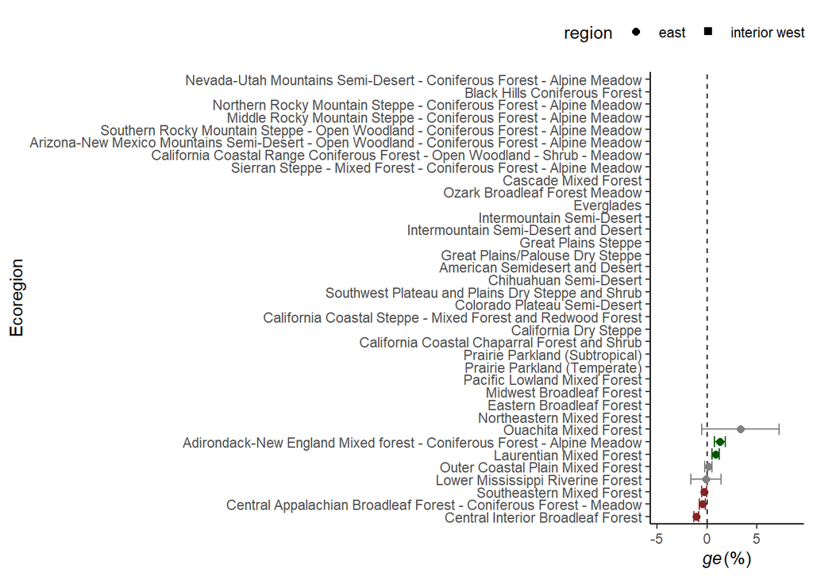

### map

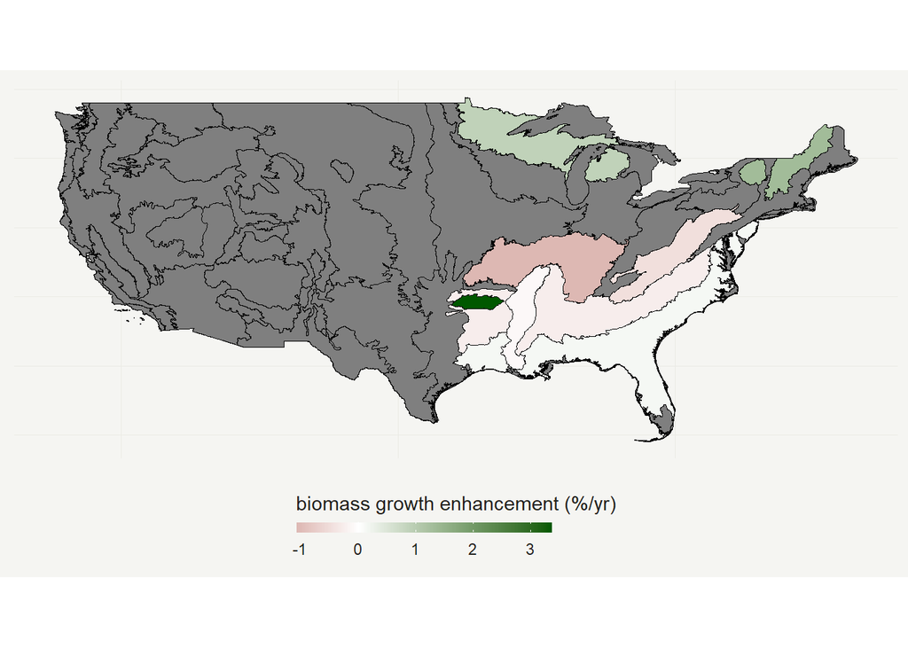

### map2

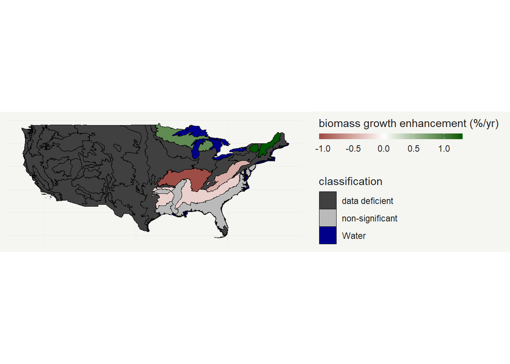

## plot phi (effect of DeltaPDSI)

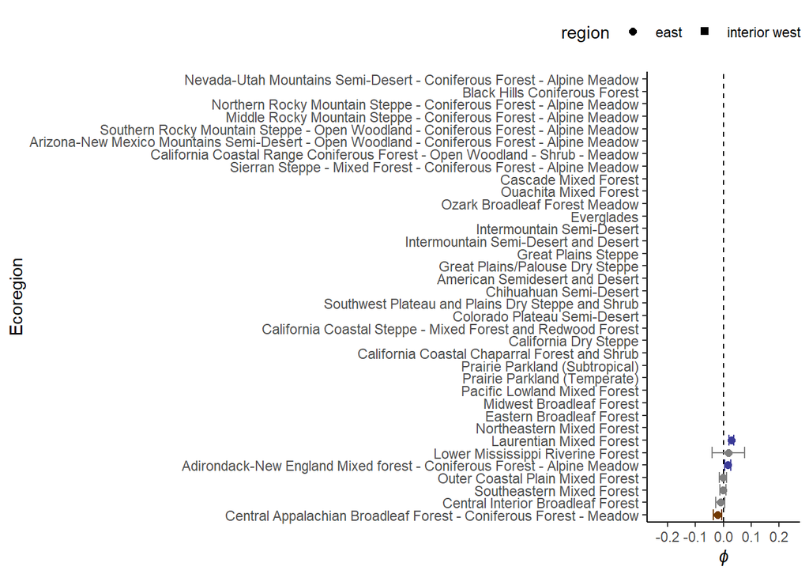

## plot alpha (biomass growth compensation effect)

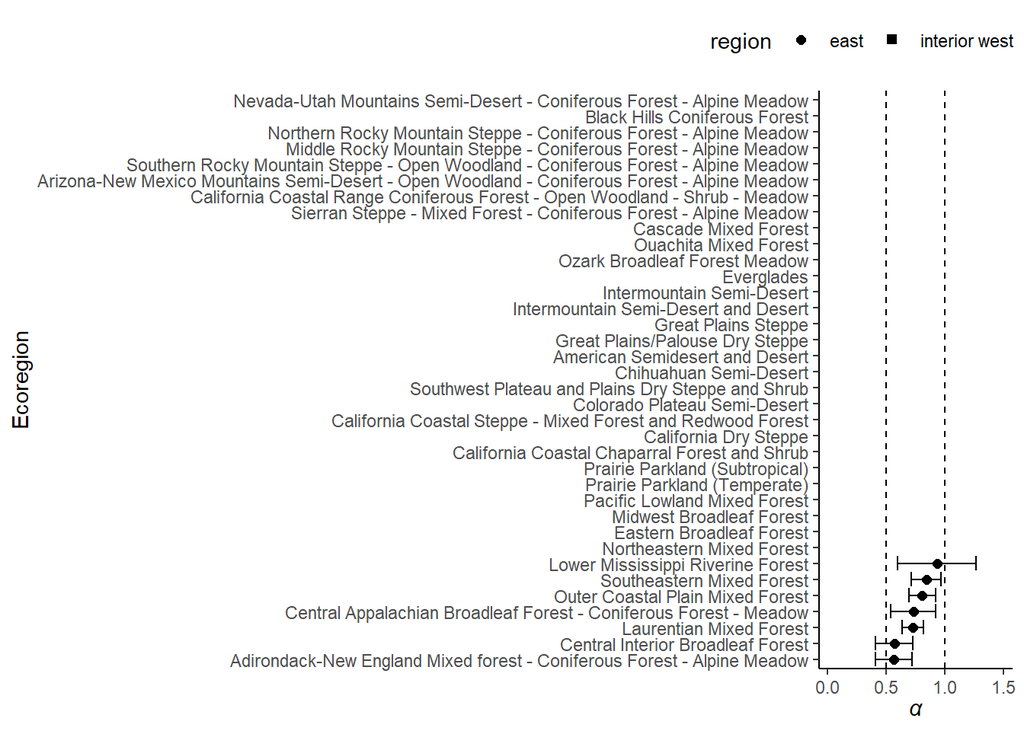

## plot a coefficient

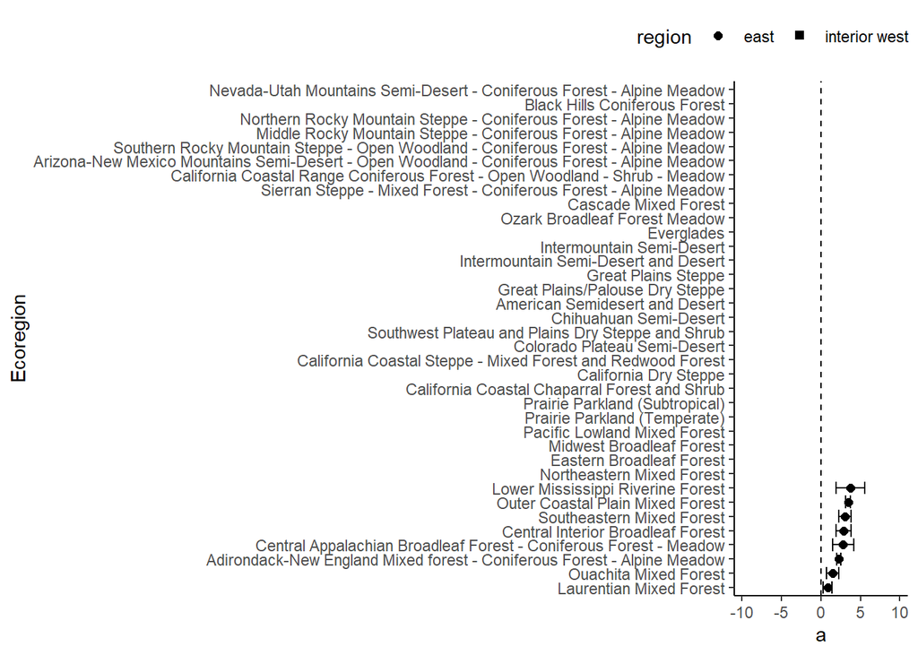

## plot b coefficient

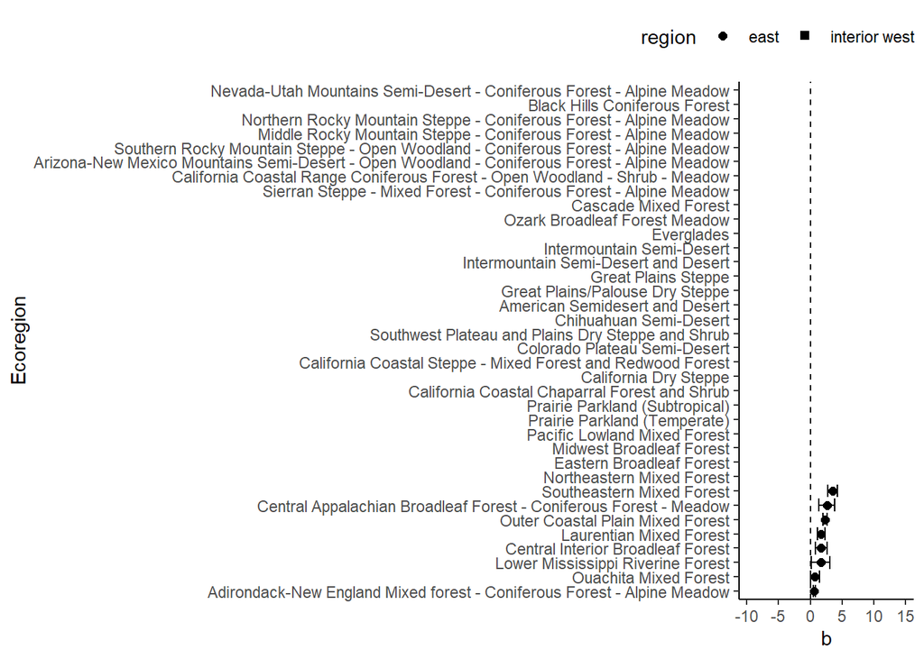